# R Notebook

# Question 1.

## Load in the libraries you need, and look at the backpack data. Take note of variable names and dimensions.

|  | backpack_weight | body_weight | ratio | back_problems | major | year | sex | status | units |
| --- | --- | --- | --- | --- | --- | --- | --- | --- | --- |
| 1 | 9 | 125 | 0.072 | 1 | Bio | 3 | Female | U | 13 |

# Question 2.

## What is the distribution of backpack weights that students are carrying? Choose an appropriate graph to show the distribution.

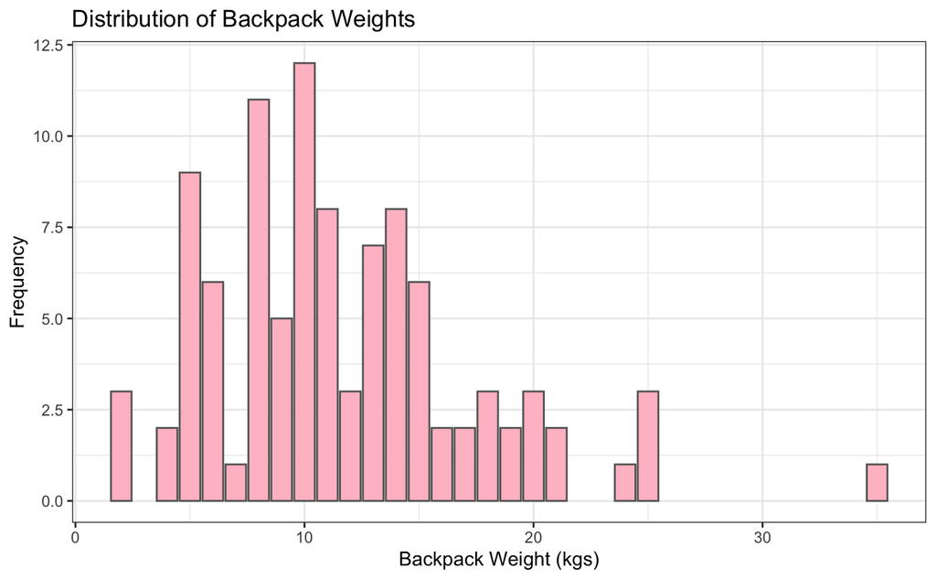

**Interpretation**

From this bar chart we can view the distribution of backpack weights in our data set. It appears that most of our backpacks are clustered between 5-15kg. The plot also shows that the data is skewed to the right, with a few outliers creating a right tail. We could say that this data is not normal, but instead positively skewed.

# Question 3.

## Are there differences in backpack weight between sex?

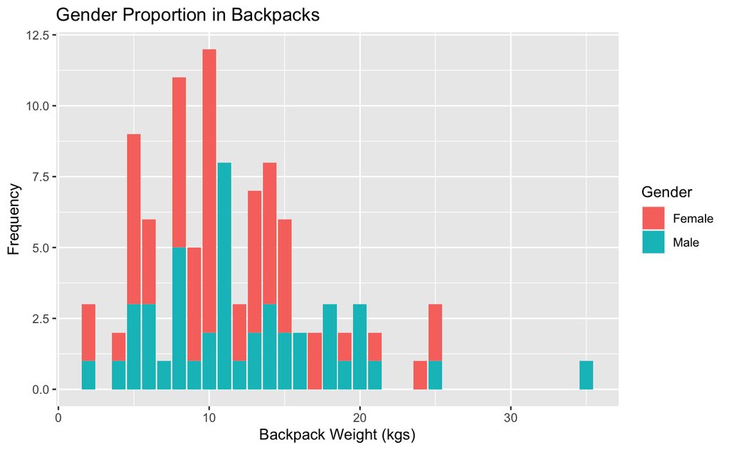

**Interpretation**

From this plot we can determine that there appears to be a great number of females wearing backpacks than males. We could also say that it appears that females tend to wear lighter backpacks. While most males seem to wear backpacks between 5-15kg, there are more males wearing backpacks greater than 15kg than females.

# Question 4.

## What is the relationship between body weight and backpack weight?

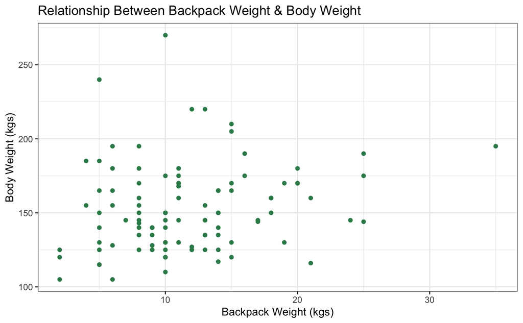

**Interpretation**

Using this scatter plot we can see that there does appear to be a relationship between backpack weight and body weight. It appears that that lighter a backpack weighs, the lighter the body weight of the person wearing it is. We can see this due to the way the points cluster in the bottom left of the plot.

# Question 5.

## Is this relationship different between men and women? Choose an appropriate plot and interpret your findings.

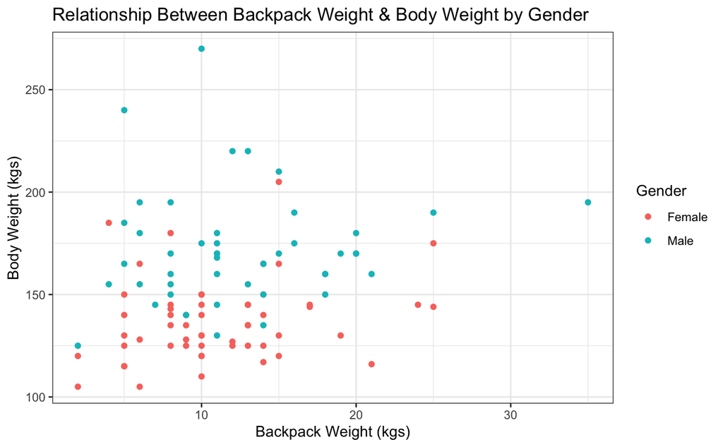

**Interpretation**

Yes, the relationship between backpack weight and body weight does seem to differ between gender. We can see that the orange points for females are clustered in a tighter group towards the bottom left corner. This shows that the females with lower body weight tend to wear lighter backpacks. In contrast for the men, we can see the teal points still show some correlation between backpack weight and body weight, however, are more spread than the points of female backpack wearers. I would guess that the correlation is stronger for female wearers than that of men. (eg correlation coefficient for female > men)

# Question 6.

## What proportion of students report back pain?

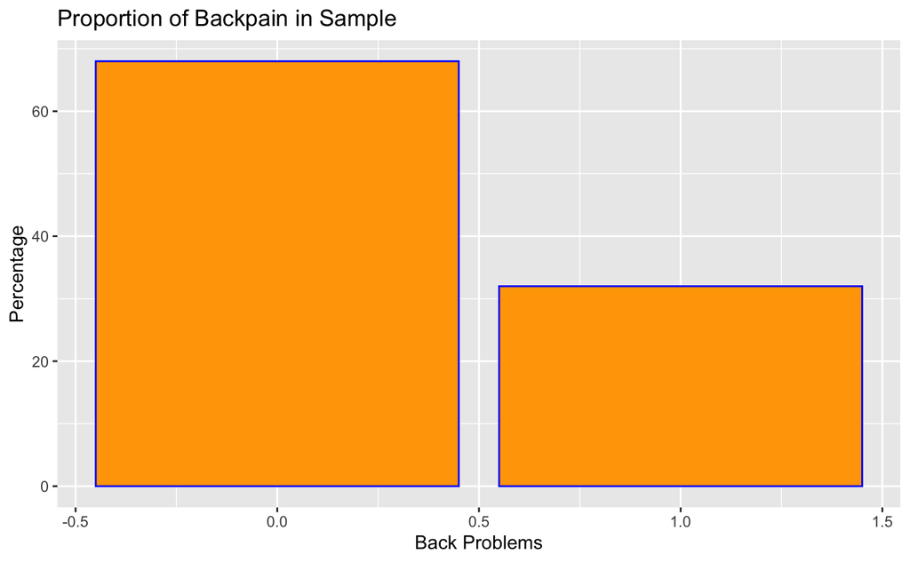

**Interpretation**

32% of students reported having backpain. 68% reported no such pain.

# Question 7.

## Is this proportion different between men and women?

```r
backpack_data %>%
  group_by(back_problems, sex) %>%
  summarise(n = n()) %>%
  mutate(freq = n / sum(n))

ggplot(backpack_data) +
  aes(x = back_problems, fill = sex)+
  geom_bar(colour = "grey30")+
  labs(title = "Proportion of Backpain in Sample",
       y = "Percentage",
       x = "Back Problems")+
  theme_bw()
```

[output not shown]

**Interpretation**

# Question 8.

## Now you’ve investigated your data separately, create plots to describe the relationship between backpack weight, body weight, gender and reported backpain.

Try both backpack_weight and body_weight as well as the ratio.

Hint: faceting would be useful here.

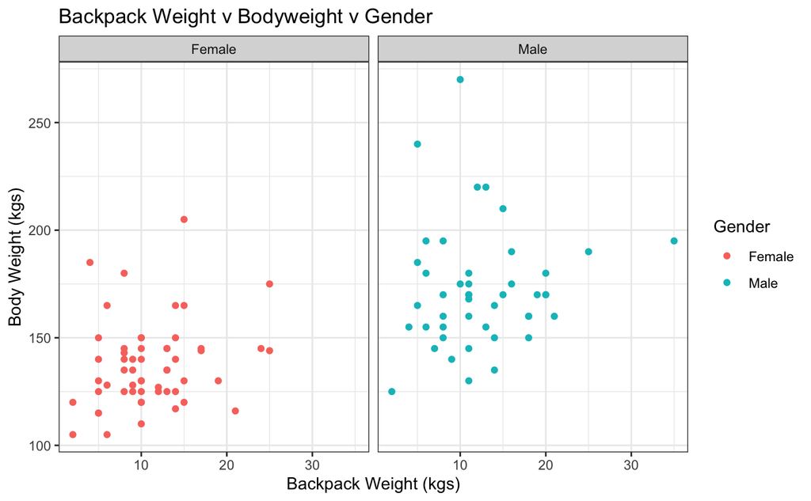

**Interpretation**

# Question 1.

## Does reported backpain differ across the year groups? Ignore year 0 in your data.

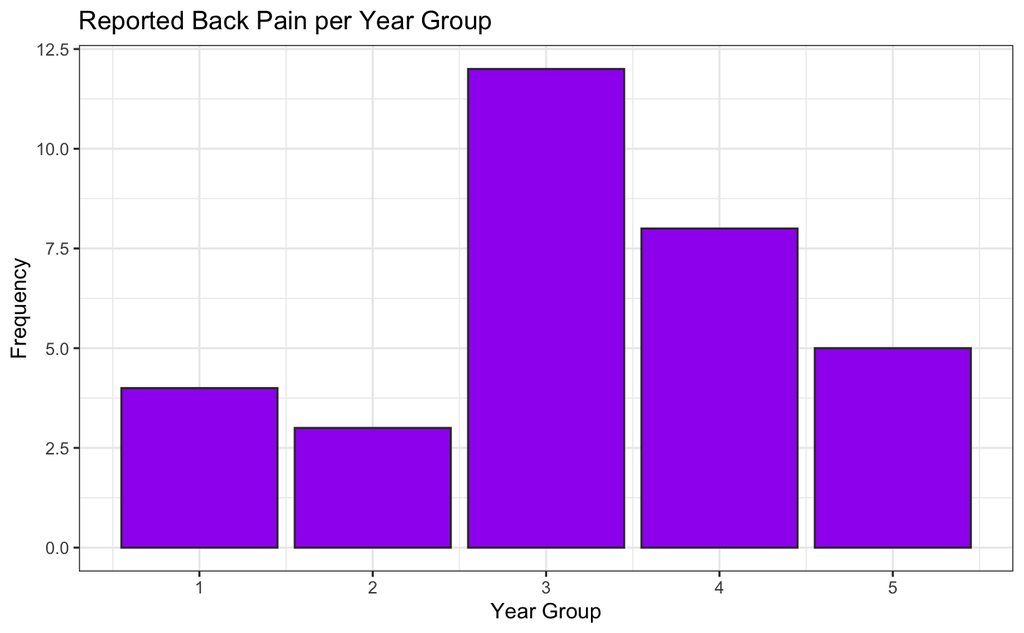

**Interpretation**

Reported backpack does differ across the year groups, with year group 3 the clear leader in terms of number of students who reported backpain with 12. The next most popular is the year group 4 with 8 cases. Years 1, 2 and 5 are closer together.

# Question 2.

## Is there a difference between how heavy the bags those in different years carry?

[figure not shown]